[News](http://diarsproject.github.io/DIARS/News.html)

[About](http://diarsproject.github.io/DIARS/About.html)

# Using remote sensing to map invasive species

Success in the strategies to manage biological invasions rely in our ability to detect and monitor species distributions. However, the field surveys designed to detect and map invasive species often take enormous logistic efforts, in time and space, and might lead to observational bias (e.g. decreased sampling effort at less accessible areas) which can negatively affect the outcome and its applicability.

Remote sensing provides standardized large-scale spatially and temporally explicit data to map and monitor changes in the environment and the distribution of native and invasive species. It helps field surveys overcome the logistical barrier and facilitates the detection and monitoring of species at multiple temporal and spatial scales. Here, as part of the DIARS project, we present a method to map invasive species using hyperspectral images.

##### The dataset

In this tutorial we will map the distribution of a invasive bryophyte species (*Campylopus introflexus*), based on the study presented in [**Skowronek et al. 2016**](http://link.springer.com/article/10.1007%2Fs10530-016-1276-1) at Sylt island (Germany) as part of the DIARS project.

For the purpose of this tutorial and in order to reduce the computer processing time (while using real remote sensing data in the analyzes), we provide an already prepared artificial image (click [HERE](http://diarsproject.github.io/DIARS/HyperProcessing.html) to read more information on the process to create this image).

Throughout the tutorial you will find this gray boxes. They contain general “best practices” tips that will help you improve the quality of the analysis when applying this framework to your own study case.

##### The framework

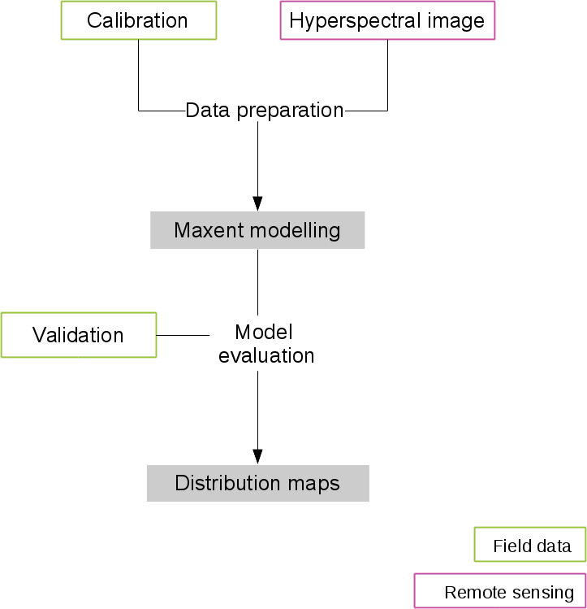

**Figure 1.** Framework used to map invasive species distribution using remote sensing data.

*You can find more information on the software we will be using in this tutorial [HERE](https://www.cs.princeton.edu/~schapire/maxent/).*

**Let’s start!**

##### Setting the R environment

Let’s start by loading the libraries that we are going to be using in this tutorial. To load the packages, it is necessary to first install them using the command `install.packages`. After installation you can load the packages in R:

```r
# Run this command if the packages are not already installed
# install.packages(c('raster','rgdal','hyperSpec','rgeos','rgrass7'))

# Load the packages
library(raster)
library(rgdal)
library(hyperSpec)
library(rgeos)
library(rgrass7)
```

Now create a folder where the datasets are going to be located and the outputs and results will be saved. To set the working directory in R to the folder created, execute the following command line, replacing the path to the folder you just created:

```r
setwd("/home/garzonc/Desktop/DIARS")
```

###### Back to the top

##### Data preparation

Three datasets are required to map the species through remote sensing: i) two shapefiles with the x,y locations of the field plots that correspond to the calibration and validation points, ii) a shapefile containing a set of points randomly distributed within the study area that do not overlap with the field plots and will serve as background points and, iii) a hyperspectral image in tiff format. You can download a sample dataset [HERE](https://drive.google.com/open?id=0B7N1GPwSz5AIbkxDbEgtbnQwYUE) and save them in the working directory you just created.

Remember to write down the resolution, projection and geographic region of all your shape and raster files. Make sure they match!

### **Setting up the field and remote sensing based-data**

The first step in the mapping process is to link the field data with the hyperspectral data, that is, to extract the hyperspectral values (reflectances at different wavelenghts) at each x,y location of the validation, calibration and background points. Let’s start!

To extract the spectral values for calibration, validation and background points we first need to load the hyperspectral image in R. Here we also plot the hyperspectral imagery and the field plots to check that all of the field plots are located within the hyperspectral image.

```r
# Create a RasterStack object with the hyperspectral bands in tiff format
layers <- stack("mosaic_datasetSyltMix.tiff")
# Explore and visualize the bands in the RasterStack
layers
```

```
## class       : RasterStack
## dimensions  : 180, 175, 31500, 248  (nrow, ncol, ncell, nlayers)
## resolution  : 1.8, 1.8  (x, y)
## extent      : 469443.6, 469758.6, 6075848, 6076172  (xmin, xmax, ymin, ymax)
## coord. ref. : +proj=utm +zone=32 +datum=WGS84 +units=m +no_defs +ellps=WGS84 +towgs84=0,0,0
## names       : mosaic_datasetSyltMix.1, mosaic_datasetSyltMix.2, mosaic_datasetSyltMix.3, mosaic_datasetSyltMix.4, mosaic_datasetSyltMix.5, mosaic_datasetSyltMix.6, mosaic_datasetSyltMix.7, mosaic_datasetSyltMix.8, mosaic_datasetSyltMix.9, mosaic_datasetSyltMix.10, mosaic_datasetSyltMix.11, mosaic…
```

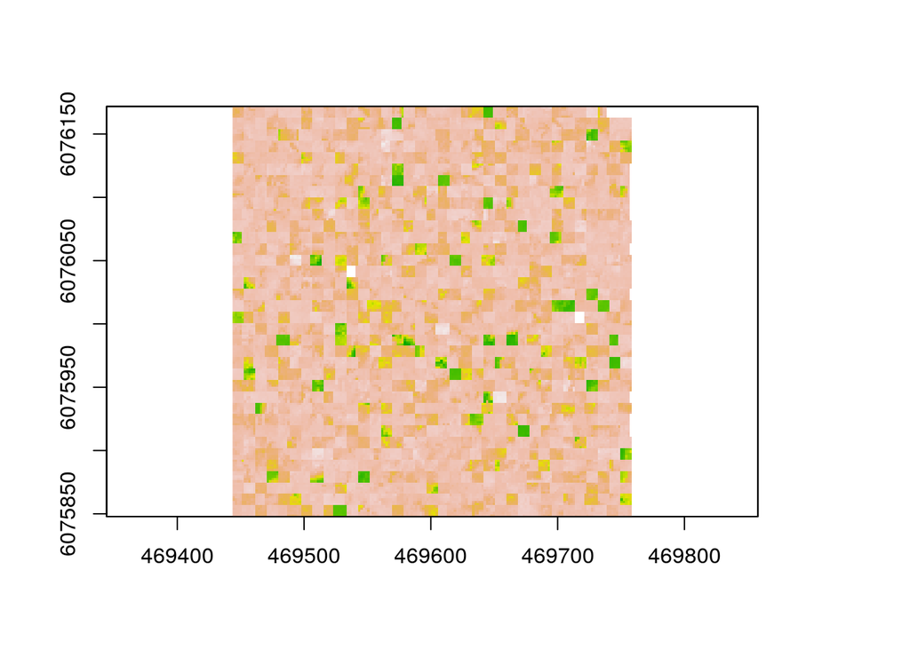

```r
plot(layers[[150]], legend = FALSE)  #Plot band 150
```

To read the point shapefiles make sure they are located in the current working folder. Initiate the GRASS software from within R, create a directory that will contain the [GRASS GIS database](https://grasswiki.osgeo.org/wiki/R_statistics/rgrass7) for the working session, set the `gisBase` argument to GRASS binaries and libraries directory path, this should be something like `C:\Program Files\GRASS GIS 7.00beta4` if your are using Windows (check [HERE](https://grasswiki.osgeo.org/wiki/R_statistics/rgrass7#GRASS_within_R) for other operating systems) and, set the correct [projection](https://grass.osgeo.org/grass70/manuals/g.proj.html), [geographic region and spatial resolution](https://grass.osgeo.org/grass70/manuals/g.proj.html) before opening any shapefile:

```r
dir.create("grassdata")  #Create a grassdata directory
```

```r
myGRASS <- "/home/garzonc/src/grass72/grass72_release/dist.x86_64-pc-linux-gnu"  #Set the location of the grass binaries and libraries
myGISDbase <- "/home/garzonc/Documents/grassData"  #Set the directory path to your GISDbase
myLocation <- "DIARS"  #Name the Location
myMapset <- "PERMANENT"  #Name the mapset

# Initiate the GRASS GIS session
initGRASS(myGRASS, home = tempdir(), gisDbase = myGISDbase, location = myLocation,
    mapset = myMapset, override = TRUE)
```

[output not shown]

```r
# Set the projection
execGRASS("g.proj", flags = c("c"), parameters = list(epsg = 32632))
```

[output not shown]

```r
# Set the region and resolution
execGRASS("g.region", parameters = list(n = "6080248.2", s = "6079942.2", e = "464307.5969",
    w = "463974.5969", res = "1.8"))
```

[output not shown]

Now the R environment is set and you can import the **calibration** points shapefile using the [v.in.ogr](https://grass.osgeo.org/grass70/manuals/v.in.ogr.html) GRASS module:

```r
execGRASS("v.in.ogr", flags = c("overwrite", "quiet"), parameters = list(input = "/home/garzonc/Desktop/DIARS/cal_pointsR.shp",
    output = "cal_pointsR"))
```

```r
pointdata_cal <- readVECT("cal_pointsR")  #Read the imported vector file
```

```
## Exporting 90 features...
##    5%  11%  17%  23%  30%  36%  42%  48%  54%  60%  66%  72%  78%  84%  90%  96% 100%
## v.out.ogr complete. 90 features (Point type) written to <cal_pointsR>
## (SQLite format).
```

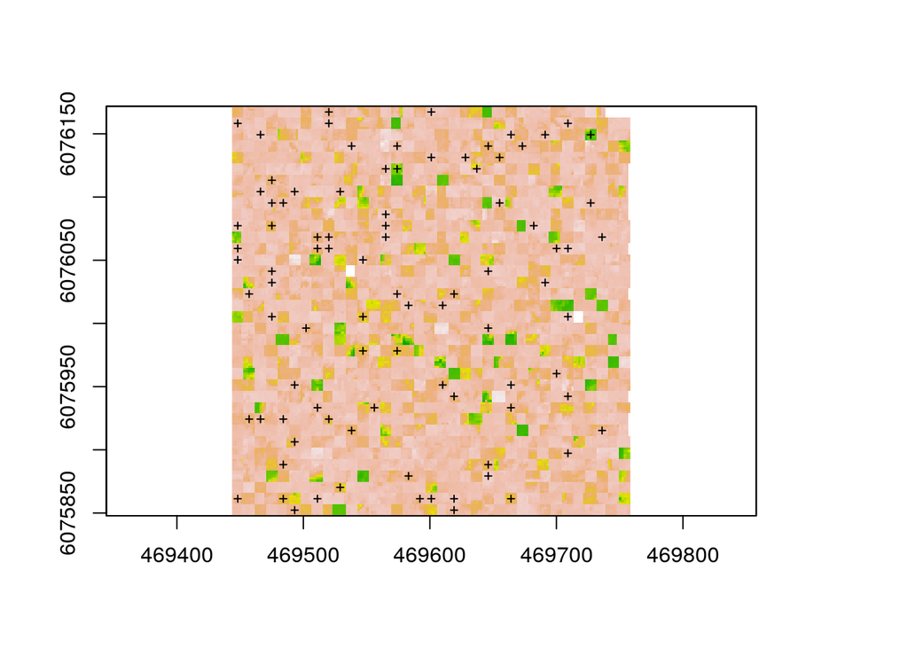

```r
layers <- stack("mosaic_datasetSyltMix.tiff")
plot(layers[[150]], legend = FALSE)  #Plot hyperspectral image band 150
points(pointdata_cal, pch = 3, cex = 0.5)  #Add the calibration points to the plot
```

Is important to also extract the values for an area around the point (buffer area) to extract the wavelenghts that reflect the plot area and so the buffer must be the same size as the field plots.

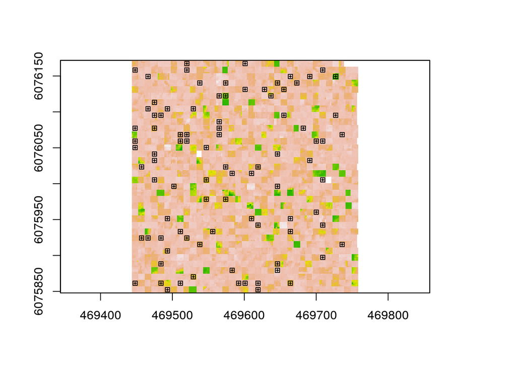

```r
# Create a buffer area of width 3 meters diameter around each point in the
# calibration points file
dataBuffer <- gBuffer(pointdata_cal, byid = T, width = 3, capStyle = "SQUARE")

# Plot the outcome
plot(layers[[150]], legend = FALSE)  #Plot band 150 of the hyperspectral image
points(pointdata_cal, pch = 3, cex = 0.3)  #Add the calibration points to the plot
plot(dataBuffer, add = TRUE)  #Add the buffer areas to the plot
```

Create a table with only the coordinates (x,y) columns

```r
pointdataXY_calB <- pointdata_cal@data[, 5:6]
```

And extract and calculate the mean value in each buffer area and for each band, and save them as “pixvals”. Then, create the “type” column and finally join all the columns (x,y coordinates, type and pixvals) and edit the row names in the table. Preview the resulting table and save it as a csv file.

```r
# Extract and calculate the mean values
pixExtract <- extract(layers, dataBuffer, method = "simple", small = T, weights = T,
    fun = mean)

type <- rep("Calibration", 90)  #Create the type column
calXY_pix <- cbind(type, pointdata_cal@data[, -c(1:4, 7:8)], pixExtract)  #Join all the columns
rownames(calXY_pix) <- pointdata_cal@data$cat  #Edit the rownames
# head(calXY_pix) #Run this line to preview the first 5 rows of the table
write.table(calXY_pix, "PointCalib.csv", quote = F)  #Save the table as a csv file
```

Now we have to follow the same procedure to extract the spectral values for the **validation** points:

```r
execGRASS("v.in.ogr", flags = c("overwrite", "quiet"), parameters = list(input = "/home/garzonc/Desktop/DIARS/val_pointsR.shp",
    output = "val_pointsR"))
```

[output not shown]

```r
pointdata_val <- readVECT("val_pointsR")
```

[output not shown]

[figure not shown]

```r
plot(layers[[150]], legend = FALSE)
```

```r
points(pointdata_val, pch = 3, cex = 0.5)
```

[output not shown]

```r
pointdataXY_val <- pointdata_val@data[, 4:5]
```

[output not shown]

```r
pixExtractV <- extract(layers, pointdataXY_val, method = "simple")
```

[output not shown]

```r
type <- rep("Validation", 166)
ValXY_pix <- cbind(type, pointdata_val@data[, -c(1:3, 6:7, 9)], pixExtractV)
```

[output not shown]

```r
rownames(ValXY_pix) <- pointdata_val@data$cat
```

[output not shown]

```r
# head(ValXY_pix) #Run this line to preview the first 5 rows of the table
write.table(ValXY_pix, "PointValid.csv", quote = F)
```

[output not shown]

Finally, we do the same for the **background** points.

```r
execGRASS("v.in.ogr", flags = c("overwrite", "quiet"), parameters = list(input = "/home/garzonc/Desktop/DIARS/back_pointsR.shp",
    output = "back_pointsR"))

pointdata_bac <- readVECT("back_pointsR")
layers <- stack("mosaic_datasetSyltMix.tiff")
plot(layers[[150]], legend = FALSE)
points(pointdata_bac, pch = 3, cex = 0.5)

pointdataXY_bac <- pointdata_bac@data[, 5:6]

pixExtractB <- extract(layers, pointdataXY_bac, method = "simple")
type <- rep("Background", 1000)
BacXY_pix <- cbind(type, pointdata_bac@data[, -c(1:4, 7:8)], pixExtractB)
rownames(BacXY_pix) <- pointdata_bac@data$cat
# head(BacXY_pix) #Run this line to preview the first 5 rows of the table
write.table(BacXY_pix, "PointBack.csv", quote = F)
```

Note that the background points must be carefully selected to reduce or avoid selecting false absences (see Lobo et al. 2010 on the selection of pseudoabsences). You can read more on the procedure followed to select pseudoabsences for the study species mapped in this tutorial in [**Skowronek et al. 2016**](http://link.springer.com/article/10.1007%2Fs10530-016-1276-1).

###### Back to the top

##### Working with maxent

When working with Maxent is important to understand the idea and become familiar with the terms in order to interpret the outcome and identify its advantages and limitations. To learn more about maxent check [Merow et al. 2013](http://onlinelibrary.wiley.com/doi/10.1111/j.1600-0587.2013.07872.x/pdf)

First, it is important to download Maxent from the website https://www.cs.princeton.edu/~schapire/maxent/), install the dismo package and, copy and paste the file `maxent.jar` in the folder called `java` of the dismo package folder:

```r
# To install dismo and maxent
install.packages("maxent", "dismo")
# Locate maxent and the java folder in dismo
system.file(package = "maxent")
system.file("java", package = "dismo")
# After copy/paste the maxent.jar in the java folder load the libraries
```

```r
library(dismo)
library(rJava)

# Set the working directory
setwd("/home/garzonc/Desktop/DIARS")
```

Load the tables with the previously extracted values for the buffer areas around the calibration points, and use the vector cal_points to select the plots with `>0` species coverage values (cam_cover column). Join the presences table with the background table, and in the resulting table omit the xy coordinates and “type” columns and only keep the spectral values. Finally create a vector `y` with 1 and 0 values corresponding to the presences (1) and background (0) rows.

```r
occs <- read.table("PointCalib.csv", header = T, sep = " ")

occsPRES <- subset(occs, occs$cam_cover > 0)
occsABS <- subset(occs, occs$cam_cover < 0.1)


occsPRES <- occsPRES[, -c(1:4)]
occsABS <- occsABS[, -c(1:4)]

Background <- read.table("PointBack.csv", header = T, sep = " ")[, -c(1:4)]
specs <- rbind(occsPRES, occsABS, Background)
specs <- specs[, -c(1, 2, 146:157, 194:220)]
y <- c(rep(1, nrow(occsPRES)), rep(0, nrow(occsABS)), rep(0, nrow(Background)))
```

The resulting tables should look like this: Table of presence (1) and absences (0) (y) and table with wavelength values per band (specs)

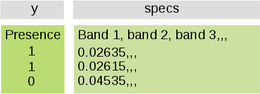

Once you have the table ready load the package [dismo](https://cran.r-project.org/web/packages/dismo/index.html) and run the model using the tables just created (y and specs) and plot the model outcome:

```r
library(dismo)
library(rJava)

me <- maxent(specs, y, args = c("addsamplestobackground=true", "applyThresholdRule=10 percentile training presence"),
    path = "./outputR")
pred <- predict(me, layers, progress = "text")
```

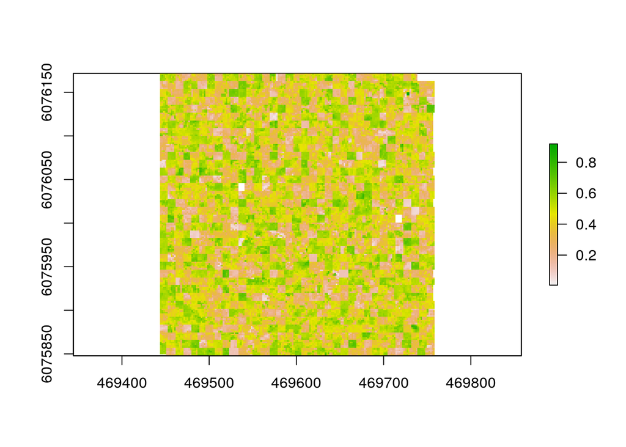

```r
plot(pred)
```

```r
# save the model outcomes
writeRaster(pred, "./outputR/map.tif", overwrite = T)
save(me, file = "./outputR/mx_obj.RData")
```

More information on species distribution modeling in R using the Dismo package can be found in https://cran.r-project.org/web/packages/dismo/vignettes/sdm.pdf

###### Back to the top

##### Model evaluation

### **How well does the model prediction fits the data?**

The aim of model evaluation is precisely to answer this question, and based on the outcome of this evaluation calculate a threshold to transform the data from probabilities of presence to a binary presence/absence map. The [evaluate](https://cran.r-project.org/web/packages/dismo/index.html) function performs a cross-validation of the model with presence/absence data. The outcomes of such evaluation are a set of thresholds with its corresponding confusion matrices and evaluation statistics.

```r
occval <- read.table("PointValid.csv", header = T, sep = " ")  #Load validation points
occsP <- subset(occval, occval$cam_cover > 0)  #presences
occsA <- subset(occval, occval$cam_cover < 0.1)  #absences
```

The validation table just created is used in the `evaluate` function to evaluate the model previously constructed. The resulting evaluation contains the outcomes of the model cross-validation, such as the True Skill Statistic (TSS) and ROC curves.

```r
y <- c(rep(1, nrow(occsP)), rep(0, nrow(occsA)))  # presence (1) and absence (0) column

occsP <- occsP[, -c(1:4)]
occsA <- occsA[, -c(1:4)]  #remove columns with data different from the wavelenght values

occsP <- occsP[, -c(1, 2, 146:157, 194:220)]
occsA <- occsA[, -c(1, 2, 146:157, 194:220)]  #remove the wavelenghts that have been excluded from the analysis

# evaluate model performance
library(dismo)
e <- evaluate(occsP, occsA, me)
e
```

```
## class          : ModelEvaluation
## n presences    : 49
## n absences     : 117
## AUC            : 0.5098552
## cor            : 0.02716758
## max TPR+TNR at : 0.2268233
```

```r
# Plot the results of the evaluation
par(mfrow = c(1, 2))
tss <- e@TPR + e@TNR - 1
plot(e@t, tss, type = "l", xlab = "Thresholds", ylab = "TSS", main = "TSS")
e@t[which.max(tss)]
```

```
## [1] 0.2268233
```

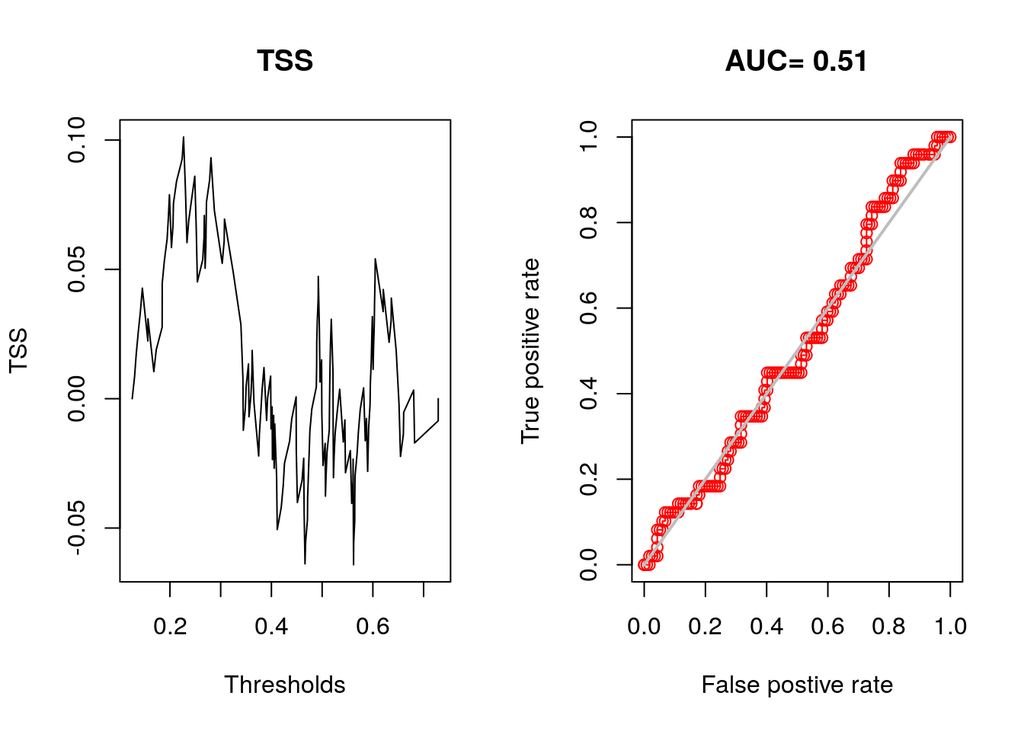

```r
plot(e, "ROC")
```

Using the `threshold` function is possible to find the set of thresholds with the highest evaluation statistics values. This information will allow us to select the threshold value at which the model probabilities should be partition to generate a binary presence/absence map.

```r
# find the thresholds that can serve to partition the model prediction in
# presence/absence
e <- evaluate(occsP, occsA, me)
th.sy = as.vector(t(threshold(e)))
th.sy
```

```
## [1] 0.6047138 0.2268233 0.1455828 0.2875774 0.4636983 0.2335773
```

```r
# evaluate again for the estimated thresholds
ev1.sy = evaluate(occsPRES, occsABS, me, tr = th.sy)
ev1.sy
```

```
## class          : ModelEvaluation
## n presences    : 60
## n absences     : 30
## AUC            : 0.8244444
## cor            : 0.533745
## max TPR+TNR at : 0.4636983
```

```r
# find the thresholds in the second model evaluation
threshold(ev1.sy)
```

```
##                kappa spec_sens no_omission prevalence equal_sens_spec
## thresholds 0.4636983 0.4636983   0.2335773  0.6047138       0.4636983
##            sensitivity
## thresholds   0.4636983
```

```r
# sort thresholds from smallest to largest
th.order.sy = sort(threshold(ev1.sy))

# get threshold value name correspondance (in order)
th.name.sy <- names(th.order.sy)
th.order.sy
```

```
##            no_omission     kappa spec_sens equal_sens_spec sensitivity
## thresholds   0.2335773 0.4636983 0.4636983       0.4636983   0.4636983
##            prevalence
## thresholds  0.6047138
```

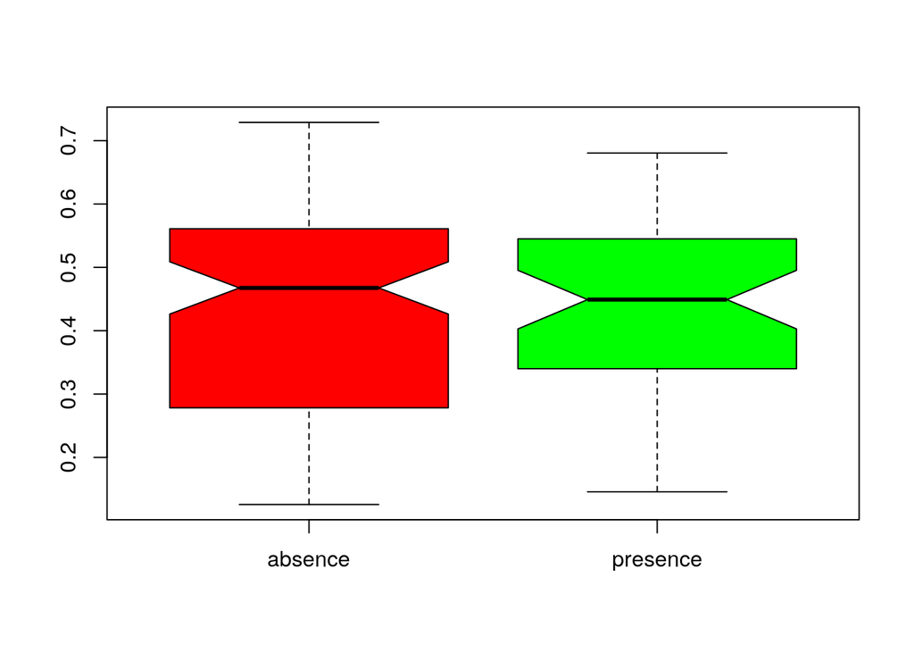

```r
# create a boxplot of the evaluation results
boxplot(e, col = c("red", "green"))
```

```r
# create an overview table
sy.ov <- cbind(th.name.sy, ev1.sy@t, ev1.sy@confusion, ev1.sy@auc, ev1.sy@CCR,
    ev1.sy@MCR, ev1.sy@kappa)
# define column names
colnames(sy.ov) <- c("Th_name", "Th_value", "tp", "fp", "fn", "tn", "AUC", "CCR",
    "MCR", "kappa")
head(sy.ov)
```

```
##      Th_name           Th_value     tp   fp   fn   tn
## [1,] "no_omission"     "0.14558278" "60" "29" "0"  "1"
## [2,] "kappa"           "0.22682327" "60" "26" "0"  "4"
## [3,] "spec_sens"       "0.23357725" "60" "26" "0"  "4"
## [4,] "equal_sens_spec" "0.28757744" "57" "24" "3"  "6"
## [5,] "sensitivity"     "0.46369834" "47" "9"  "13" "21"
## [6,] "prevalence"      "0.60471381" "12" "0"  "48" "30"
##      AUC                 CCR                 MCR
## [1,] "0.824444444444444" "0.677777777777778" "0.322222222222222"
## [2,] "0.824444444444444" "0.711111111111111" "0.288888888888889"
## [3,] "0.824444444444444" "0.711111111111111" "0.288888888888889"
## [4,] "0.824444444444444" "0.7"               "0.3"
## [5,] "0.824444444444444" "0.755555555555556" "0.244444444444444"
## [6,] "0.824444444444444" "0.466666666666667" "0.533333333333333"
##      kappa
## [1,] "0.043956043956044"
## [2,] "0.170212765957447"
## [3,] "0.170212765957447"
## [4,] "0.181818181818182"
## [5,] "0.467741935483871"
## [6,] "0.142857142857143"
```

```r
sy.ov
```

```
##      Th_name           Th_value     tp   fp   fn   tn
## [1,] "no_omission"     "0.14558278" "60" "29" "0"  "1"
## [2,] "kappa"           "0.22682327" "60" "26" "0"  "4"
## [3,] "spec_sens"       "0.23357725" "60" "26" "0"  "4"
## [4,] "equal_sens_spec" "0.28757744" "57" "24" "3"  "6"
## [5,] "sensitivity"     "0.46369834" "47" "9"  "13" "21"
## [6,] "prevalence"      "0.60471381" "12" "0"  "48" "30"
##      AUC                 CCR                 MCR
## [1,] "0.824444444444444" "0.677777777777778" "0.322222222222222"
## [2,] "0.824444444444444" "0.711111111111111" "0.288888888888889"
## [3,] "0.824444444444444" "0.711111111111111" "0.288888888888889"
## [4,] "0.824444444444444" "0.7"               "0.3"
## [5,] "0.824444444444444" "0.755555555555556" "0.244444444444444"
## [6,] "0.824444444444444" "0.466666666666667" "0.533333333333333"
##      kappa
## [1,] "0.043956043956044"
## [2,] "0.170212765957447"
## [3,] "0.170212765957447"
## [4,] "0.181818181818182"
## [5,] "0.467741935483871"
## [6,] "0.142857142857143"
```

```r
# save results
write.csv(sy.ov, "sy.overview.csv", quote = FALSE, row.names = FALSE)
```

###### Back to the top

##### Distribution map

```r
e <- evaluate(occsP, occsA, me)
# Plot the model prediction
par(mfrow = c(1, 1))
tr <- threshold(e, "kappa")
tr
```

```
## [1] 0.6047138
```

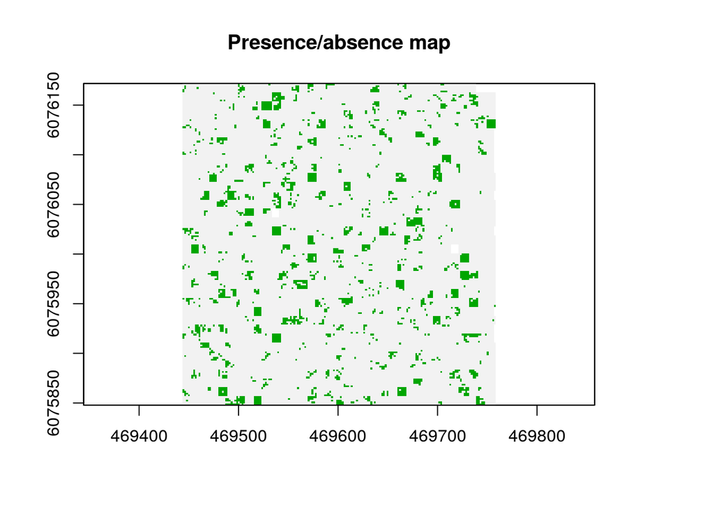

```r
plot(pred > tr, main = "Presence/absence map", legend = FALSE)
```

```r
# See all the outcomes of the model evaluation
str(e)
```

```
## Formal class 'ModelEvaluation' [package "dismo"] with 22 slots
##   ..@ presence  : num [1:49] 0.401 0.545 0.506 0.535 0.465 ...
##   ..@ absence   : num [1:117] 0.476 0.515 0.592 0.419 0.636 ...
##   ..@ np        : int 49
##   ..@ na        : int 117
##   ..@ auc       : num 0.51
##   ..@ pauc      : num(0)
##   ..@ cor       : Named num 0.0272
##   .. ..- attr(*, "names")= chr "cor"
##   ..@ pcor      : num 0.728
##   ..@ t         : num [1:168] 0.126 0.13 0.133 0.138 0.142 ...
##   ..@ confusion : int [1:168, 1:4] 49 49 49 49 49 49 48 48 47 47 ...
##   .. ..- attr(*, "dimnames")=List of 2
##   .. .. ..$ : NULL
##   .. .. ..$ : chr [1:4] "tp" "fp" "fn" "tn"
##   ..@ prevalence: num [1:168] 0.295 0.295 0.295 0.295 0.295 ...
##   ..@ ODP       : num [1:168] 0.705 0.705 0.705 0.705 0.705 ...
##   ..@ CCR       : num [1:168] 0.295 0.301 0.307 0.313 0.319 ...
##   ..@ TPR       : num [1:168] 1 1 1 1 1 ...
##   ..@ TNR       : num [1:168] 0 0.00855 0.01709 0.02564 0.03419 ...
##   ..@ FPR       : num [1:168] 1 0.991 0.983 0.974 0.966 ...
##   ..@ FNR       : num [1:168] 0 0 0 0 0 ...
##   ..@ PPP       : num [1:168] 0.295 0.297 0.299 0.301 0.302 ...
##   ..@ NPP       : num [1:168] NaN 1 1 1 1 ...
##   ..@ MCR       : num [1:168] 0.705 0.699 0.693 0.687 0.681 ...
##   ..@ OR        : num [1:168] NaN Inf Inf Inf Inf ...
##   ..@ kappa     : num [1:168] 0 0.00506 0.01016 0.0153 0.02047 ...
```

###### Back to the top

##### References

**Merow, C., Smith, M. J. and Silander, J. A.** (2013), A practical guide to MaxEnt for modeling species’ distributions: what it does, and why inputs and settings matter. Ecography, 36: 1058–1069. [doi:10.1111/j.1600-0587.2013.07872.x](http://onlinelibrary.wiley.com/doi/10.1111/j.1600-0587.2013.07872.x/abstract)

**Segurado, P. and Araújo, M. B.** (2004), An evaluation of methods for modelling species distributions. Journal of Biogeography, 31: 1555–1568. [doi:10.1111/j.1365-2699.2004.01076.x](http://onlinelibrary.wiley.com/doi/10.1111/j.1365-2699.2004.01076.x/abstract)

**Skowronek, S., Ewald, M., Isermann, M. et al.** (2016). Mapping an invasive bryophyte species using hyperspectral remote sensing data. Biol Invasions [doi:10.1007/s10530-016-1276-1](http://link.springer.com/article/10.1007%2Fs10530-016-1276-1)

###### Back to the top

**Authors**: Sandra Skowronek, Carol Garzon-Lopez, Tarek Hattab, Duccio Rocchini & Jonathan Lenoir

**Date**: 2017-07-05

*Built with RMarkdown and hosted on Github Pages.*